# Tidy assignment - flights data

Henry Owens

3/8/2021

## Loading the data in original wide format

I used google sheets to make a wide format csv of the table in the assignment (avoiding the empty rows and cells).

```r
arrivals <- read.csv("/Users/henrybowens/Documents/CUNY MSDS/DATA 607/Tidy and transform/arrivals.csv")
arrivals
```

```
##   airline  status los_angeles phoenix san_diego san_franciso seattle
## 1  Alaska on time         497     221       212          503    1841
## 2  Alaska delayed          62      12        20          102     305
## 3 AM West on time         694    4840       383          320     201
## 4 AM West delayed         117     415        65          129      61
```

## Pivot the data to tidy format

Using pivot_longer (which is the newer version of “gather”, I learned), we can turn the numerical columns into a single column accompanied by a categorical column for the five destinations. This is a tidy data set where each row is an observation of flights per airline, per arrival status, and per destination. Take a look!

Note: I found it useful to use “!airline & !status” arg to exclude the categorical columns and run the pivot as desired.

```r
arrivals <- arrivals %>% pivot_longer(!airline & !status, names_to = "destination", values_to = "flights")
arrivals
```

```
## # A tibble: 20 x 4
##    airline status  destination  flights
##    <chr>   <chr>   <chr>          <int>
##  1 Alaska  on time los_angeles      497
##  2 Alaska  on time phoenix          221
##  3 Alaska  on time san_diego        212
##  4 Alaska  on time san_franciso     503
##  5 Alaska  on time seattle         1841
##  6 Alaska  delayed los_angeles       62
##  7 Alaska  delayed phoenix           12
##  8 Alaska  delayed san_diego         20
##  9 Alaska  delayed san_franciso     102
## 10 Alaska  delayed seattle          305
## 11 AM West on time los_angeles      694
## 12 AM West on time phoenix         4840
## 13 AM West on time san_diego        383
## 14 AM West on time san_franciso     320
## 15 AM West on time seattle          201
## 16 AM West delayed los_angeles      117
## 17 AM West delayed phoenix          415
## 18 AM West delayed san_diego         65
## 19 AM West delayed san_franciso     129
## 20 AM West delayed seattle           61
```

## Airline performance

How do the airlines stack up by on time vs delayed?

```r
arrivals %>% group_by(airline, status) %>%
  summarise(flights = sum(flights))
```

```
## # A tibble: 4 x 3
## # Groups:   airline [2]
##   airline status  flights
##   <chr>   <chr>     <int>
## 1 Alaska  delayed     501
## 2 Alaska  on time    3274
## 3 AM West delayed     787
## 4 AM West on time    6438
```

## Plotting the flights by destination and airline

Of these the big destinations are AM West to Phoenix (overwhelmingly) and Alaska to Seattle.

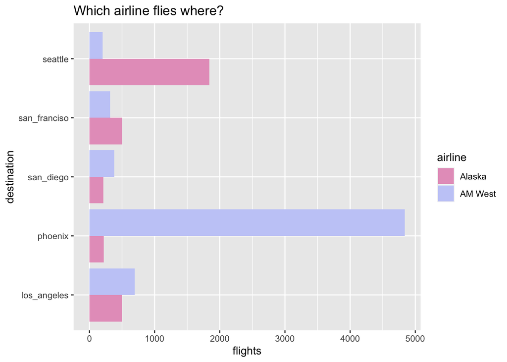

```r
ggplot(data = arrivals,
       mapping = aes(x = destination, y = flights, fill = airline)) +
  geom_col(position = "dodge") +
  scale_fill_manual(values=wes_palette(n=2, name="GrandBudapest2")) +
  coord_flip() +
  ggtitle("Which airline flies where?")
```

## Plotting flight arrival performance

Looking at the proportion of on time to delayed arrivals, by destination and airline. We can see that generally Alaska has a better portion of on time arrivals. The destinations seem to have relatively similar on-time proportions (i.e., SF is the lowest and Phoenix is the highest) for both airlines, with Alaska performing better at each destination.

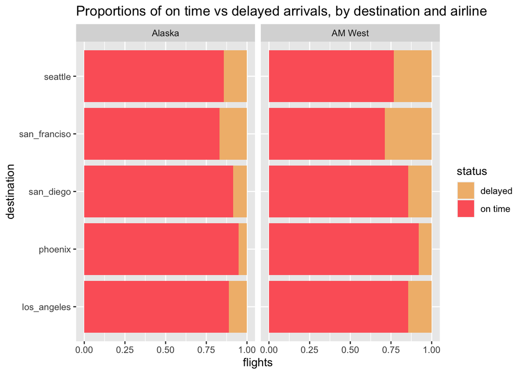

```r
ggplot(data = arrivals,
       mapping = aes(x = destination, y = flights, fill = status)) +
  geom_col(position = "fill") +
  facet_wrap(~ airline) +
  scale_fill_manual(values=wes_palette(n=2, name="GrandBudapest1")) +
  coord_flip() +
  ggtitle("Proportions of on time vs delayed arrivals, by destination and airline")
```

## Wait one minute: A Paradox!

We have a paradox where Alaska airlines consistently performs better than AM West at every destination, BUT in the aggregate more AM West flights land on time. This is very interesting!! I can see that it has something to do with the big volume discrepancies between Phoenix and Seattle, so arithmetically it could sense, but intuitively it is hard to comprehend.

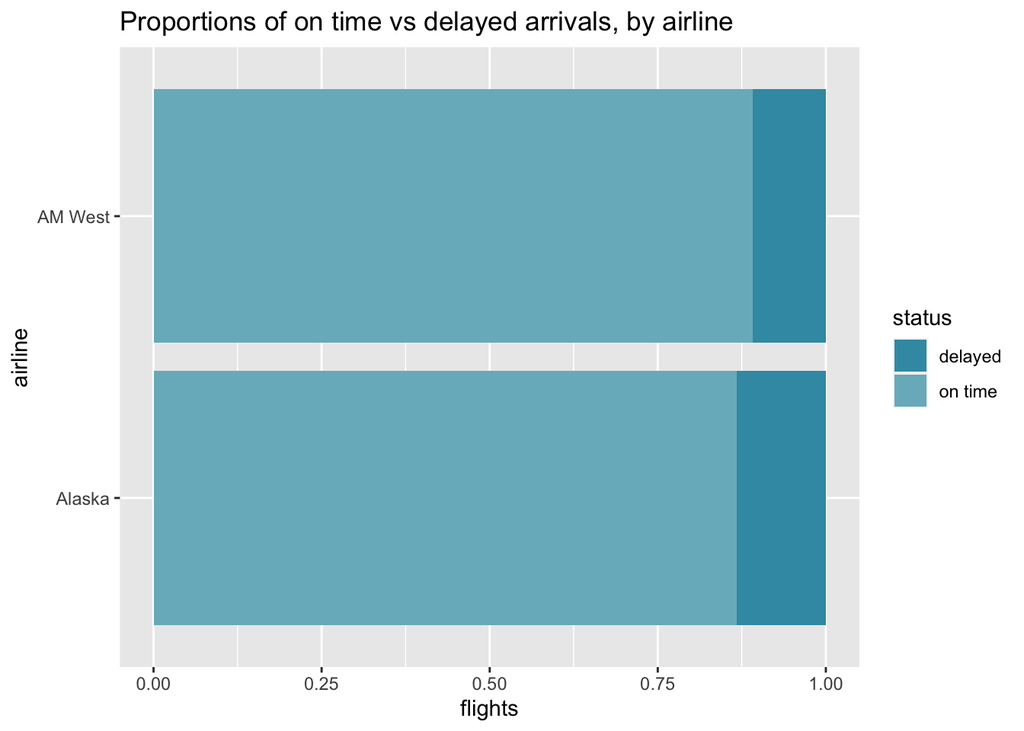

```r
ggplot(data = arrivals,
       mapping = aes(x = airline, y = flights, fill = status)) +
  geom_col(position = "fill") +
  scale_fill_manual(values=wes_palette(n=2, name="Zissou1")) +
  ggtitle("Proportions of on time vs delayed arrivals, by airline") +
  coord_flip()
```

## Conclusions

I suppose that, all else equal, I would be tempted to book a flight with Alaska over AM West, since destination-wise their flights are more likely to arrive on time. But I would have to think more about this. I forget the name of this paradox, but this is a great illustration of it.